# KI - Project

Anna Sofie Christensen, Carrie Lovejoy, Sofie Schubert Elving

2022-12-30

```r
library(tidyverse)
library(dplyr)
library("survival")
library("truncreg")
```

The data set can be found here: https://www.kaggle.com/datasets/reihanenamdari/breast-cancer?resource=download

## 1) The data and alterations

```r
bc <- read.csv("C:/Users/sofel/OneDrive/Dokumenter/AarhusUniversitet/3.semester/KI/R/Breast_Cancer.csv")
```

We alternate our data a bit:

We first change our Age variable to be age after 30:

```r
bc$Age <- bc$Age - 30
```

Then changing Status, Progesterone.Status and Estrogen.Status to dummy variables and renaming those:

```r
bc$Status <- ifelse(bc$Status == "Dead", 1, 0)
bc$Progesterone.Status <- ifelse(bc$Progesterone.Status == "Positive", 1, 0)
bc$Estrogen.Status <- ifelse(bc$Estrogen.Status == "Positive", 1, 0)
```

```r
bc <- bc %>%
  rename(
    Dead = "Status",
    Prog.Pos = "Progesterone.Status",
    Estro.Pos = "Estrogen.Status",
    Reg.N.Pos = "Reginol.Node.Positive",
    Reg.N.Ex = "Regional.Node.Examined"
  )
```

## 2) Interaction terms

We add an age^2 variable:

```r
bc$Agesq <- bc$Age^2
```

For Regional.Node.Examined and Regional.Node.Positive, we can’t have more positive lymph nodes than we have examined. This can be seen in this plot:

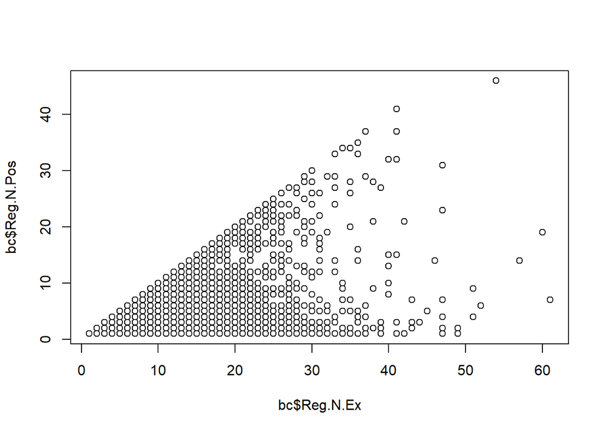

```r
plot(bc$Reg.N.Ex, bc$Reg.N.Pos)
```

## 3) Used models

The three models we test on are given here.

### Model 1

Model of the data, leaving out variables that are linked (perfect multicollinearity)
$$\begin{aligned}
SurvivalMonths_i &= \beta_0 + \beta_1 Age_i + \beta_2 Race_i +
\beta_3 MaritalStatus_i + \beta_4 Grade_i \\
& \quad + \beta_5 AStage_i + \beta_6 TumorSize_i + \beta_7
EstroPos_i + \beta_8 ProgPos_i \\
& \quad + \beta_9 RegNPos_i + \beta_{10} RegNEx_i + u_i
\end{aligned}$$

### Model 2

Model 1 with interaction terms and MaritalStatus dropped
$$\begin{aligned}
SurvivalMonths_i &= \beta_0 + \beta_1 Age_i + \beta_2 Age^2_i +
\beta_3 Race_i + \beta_4 Grade_i + \beta_5 AStage_i \\
& \quad + \beta_6 TumorSize_i + \beta_7 EstroPos_i + \beta_8
ProgPos_i \\
& \quad + \beta_9 (EstroPos_i \cdot ProgPos_i) \\ \nonumber
& \quad + \beta_{10} RegNPos_i + \beta_{11} (RegNPos_i \cdot
RegNEx_i) + u_i
\end{aligned}$$

### Model 3

Model 2 without the EstroPos and ProgPos interaction term.
$$\begin{aligned}
\nonumber SurvivalMonths_i &= \beta_0 + \beta_1 Age_i + \beta_2
Age^2_i + \beta_3 Race_i + \beta_4 Grade_i + \beta_5 AStage_i \\
& \quad + \beta_6 TumorSize_i + \beta_7 EstroPos_i + \beta_8
ProgPos_i + \beta_9 RegNPos_i \\ \nonumber
& \quad + \beta_{10} (RegNPos_i \cdot RegNEx_i) + u_i
\end{aligned}$$

## 4) Naive OLS

We run a naive OLS on model 1:

```r
LM1 <-
  lm(
    data = bc,
    formula = Survival.Months ~ Age + Race + Marital.Status + Grade + A.Stage + Tumor.Size + Estro.Pos + Prog.Pos + Reg.N.Pos + Reg.N.Ex
  )
summary(LM1)
```

```
##
## Call:
## lm(formula = Survival.Months ~ Age + Race + Marital.Status +
##     Grade + A.Stage + Tumor.Size + Estro.Pos + Prog.Pos + Reg.N.Pos +
##     Reg.N.Ex, data = bc)
##
## Residuals:
##     Min      1Q  Median      3Q     Max
## -74.190 -15.518   1.217  18.194  56.911
##
## Coefficients:
##                         Estimate Std. Error t value Pr(>|t|)
## (Intercept)             53.85707    6.21312   8.668  < 2e-16 ***
## Age                     -0.04303    0.04132  -1.042  0.29770
## RaceOther                5.52728    1.84696   2.993  0.00278 **
## RaceWhite                3.72212    1.40023   2.658  0.00789 **
## Marital.StatusMarried    0.77867    1.11474   0.699  0.48489
## Marital.StatusSeparated -6.34687    3.51681  -1.805  0.07119 .
## Marital.StatusSingle    -0.01727    1.37652  -0.013  0.98999
## Marital.StatusWidowed   -0.82679    1.80739  -0.457  0.64737
## Grade1                   3.20673    5.27410   0.608  0.54321
## Grade2                   3.08130    5.20079   0.592  0.55357
## Grade3                   1.91375    5.21348   0.367  0.71358
## A.StageRegional          4.68853    2.44999   1.914  0.05573 .
## Tumor.Size              -0.05409    0.01748  -3.094  0.00199 **
## Estro.Pos                8.59036    1.68396   5.101 3.53e-07 ***
## Prog.Pos                 1.65325    1.10032   1.503  0.13304
## Reg.N.Pos               -0.51804    0.08036  -6.446 1.28e-10 ***
## Reg.N.Ex                 0.10890    0.04815   2.262  0.02376 *
## ---
## Signif. codes:  0 '***' 0.001 '**' 0.01 '*' 0.05 '.' 0.1 ' ' 1
##
## Residual standard error: 22.47 on 4007 degrees of freedom
## Multiple R-squared:  0.0429, Adjusted R-squared:  0.03908
## F-statistic: 11.23 on 16 and 4007 DF,  p-value: < 2.2e-16
```

And on model 2:

```r
LM2 <-
  lm(
    data = bc,
    formula = Survival.Months ~ Age + Agesq + Race + Grade + A.Stage + Tumor.Size + Estro.Pos *
      Prog.Pos + Reg.N.Pos + Reg.N.Ex:Reg.N.Pos
  )
summary(LM2)
```

```
##
## Call:
## lm(formula = Survival.Months ~ Age + Agesq + Race + Grade + A.Stage +
##     Tumor.Size + Estro.Pos * Prog.Pos + Reg.N.Pos + Reg.N.Ex:Reg.N.Pos,
##     data = bc)
##
## Residuals:
##     Min      1Q  Median      3Q     Max
## -73.923 -15.520   1.225  18.197  57.683
##
## Coefficients:
##                      Estimate Std. Error t value Pr(>|t|)
## (Intercept)         48.595532   6.367492   7.632 2.87e-14 ***
## Age                  0.509584   0.190250   2.679 0.007425 **
## Agesq               -0.012134   0.004037  -3.006 0.002665 **
## RaceOther            6.034958   1.822154   3.312 0.000935 ***
## RaceWhite            3.993288   1.377540   2.899 0.003766 **
## Grade1               3.604228   5.278878   0.683 0.494795
## Grade2               3.714988   5.204010   0.714 0.475349
## Grade3               2.672368   5.215430   0.512 0.608402
## A.StageRegional      4.623275   2.448625   1.888 0.059083 .
## Tumor.Size          -0.048343   0.017602  -2.746 0.006052 **
## Estro.Pos           10.197832   1.810962   5.631 1.91e-08 ***
## Prog.Pos            12.545689   4.569143   2.746 0.006064 **
## Reg.N.Pos           -0.853578   0.183399  -4.654 3.36e-06 ***
## Estro.Pos:Prog.Pos -11.410798   4.700818  -2.427 0.015251 *
## Reg.N.Pos:Reg.N.Ex   0.014942   0.006248   2.392 0.016823 *
## ---
## Signif. codes:  0 '***' 0.001 '**' 0.01 '*' 0.05 '.' 0.1 ' ' 1
##
## Residual standard error: 22.44 on 4009 degrees of freedom
## Multiple R-squared:  0.04532,    Adjusted R-squared:  0.04198
## F-statistic: 13.59 on 14 and 4009 DF,  p-value: < 2.2e-16
```

## 5) Truncation

We use the truncreg() function to test our regression taking truncation into consideration.

We first do this on model 1:

```r
trunc1 <-
  truncreg(
    data = bc,
    formula = Survival.Months ~ Age + Race + Marital.Status + Grade + A.Stage + Tumor.Size + Estro.Pos + Prog.Pos + Reg.N.Pos + Reg.N.Ex,
    point = 1.0,
    direction = "left"
  )
summary(trunc1)
```

```
##
## Call:
## truncreg(formula = Survival.Months ~ Age + Race + Marital.Status +
##     Grade + A.Stage + Tumor.Size + Estro.Pos + Prog.Pos + Reg.N.Pos +
##     Reg.N.Ex, data = bc, point = 1, direction = "left")
##
## BFGS maximization method
## 41 iterations, 0h:0m:0s
## g'(-H)^-1g = 0.00077
##
##
##
## Coefficients :
##                          Estimate Std. Error t-value  Pr(>|t|)
## (Intercept)             53.507719   6.320691  8.4655 < 2.2e-16 ***
## Age                     -0.043578   0.041716 -1.0446  0.296196
## RaceOther                5.621027   1.868004  3.0091  0.002620 **
## RaceWhite                3.789891   1.419302  2.6703  0.007579 **
## Marital.StatusMarried    0.786149   1.125998  0.6982  0.485064
## Marital.StatusSeparated -6.566474   3.591711 -1.8282  0.067515 .
## Marital.StatusSingle    -0.015222   1.390650 -0.0109  0.991267
## Marital.StatusWidowed   -0.836181   1.827175 -0.4576  0.647214
## Grade1                   3.121315   5.362436  0.5821  0.560519
## Grade2                   3.001272   5.289144  0.5674  0.570415
## Grade3                   1.816613   5.302238  0.3426  0.731890
## A.StageRegional          4.809065   2.503875  1.9206  0.054776 .
## Tumor.Size              -0.054848   0.017704 -3.0981  0.001947 **
## Estro.Pos                8.813767   1.715143  5.1388 2.765e-07 ***
## Prog.Pos                 1.668089   1.111840  1.5003  0.133538
## Reg.N.Pos               -0.528490   0.081751 -6.4646 1.016e-10 ***
## Reg.N.Ex                 0.110097   0.048575  2.2665  0.023418 *
## sigma                   22.554407   0.259027 87.0737 < 2.2e-16 ***
## ---
## Signif. codes:  0 '***' 0.001 '**' 0.01 '*' 0.05 '.' 0.1 ' ' 1
##
## Log-Likelihood: -18220 on 18 Df
```

Then on model 2:

```r
trunc2 <-
  truncreg(
    data = bc,
    formula = Survival.Months ~ Age + Agesq + Race + Grade + A.Stage + Tumor.Size + Estro.Pos *
      Prog.Pos + Reg.N.Pos + Reg.N.Ex:Reg.N.Pos,
    point = 1.0,
    direction = "left"
  )
summary(trunc2)
```

```
##
## Call:
## truncreg(formula = Survival.Months ~ Age + Agesq + Race + Grade +
##     A.Stage + Tumor.Size + Estro.Pos * Prog.Pos + Reg.N.Pos +
##     Reg.N.Ex:Reg.N.Pos, data = bc, point = 1, direction = "left")
##
## BFGS maximization method
## 60 iterations, 0h:0m:1s
## g'(-H)^-1g = 0.0025
##
##
##
## Coefficients :
##                       Estimate  Std. Error t-value  Pr(>|t|)
## (Intercept)         48.1387779   6.4799843  7.4288 1.095e-13 ***
## Age                  0.5173531   0.1925500  2.6869 0.0072129 **
## Agesq               -0.0123124   0.0040847 -3.0143 0.0025757 **
## RaceOther            6.1433750   1.8434578  3.3325 0.0008606 ***
## RaceWhite            4.0699066   1.3968274  2.9137 0.0035720 **
## Grade1               3.4892447   5.3674261  0.6501 0.5156419
## Grade2               3.6072511   5.2925903  0.6816 0.4955132
## Grade3               2.5503204   5.3044030  0.4808 0.6306635
## A.StageRegional      4.7730049   2.5029298  1.9070 0.0565248 .
## Tumor.Size          -0.0490444   0.0178279 -2.7510 0.0059415 **
## Estro.Pos           10.4537046   1.8472919  5.6589 1.523e-08 ***
## Prog.Pos            12.6872336   4.6174327  2.7477 0.0060018 **
## Reg.N.Pos           -0.8682568   0.1861072 -4.6654 3.081e-06 ***
## Estro.Pos:Prog.Pos -11.5367055   4.7503560 -2.4286 0.0151573 *
## Reg.N.Pos:Reg.N.Ex   0.0151798   0.0063417  2.3936 0.0166827 *
## sigma               22.5257583   0.2586715 87.0825 < 2.2e-16 ***
## ---
## Signif. codes:  0 '***' 0.001 '**' 0.01 '*' 0.05 '.' 0.1 ' ' 1
##
## Log-Likelihood: -18214 on 16 Df
```

## 6) Censoring

We use the survreg()-function to take our right sided censoring into consideration

First on model 1:

```r
tobit1 <-
  survreg(
    data = bc,
    formula = Surv(Survival.Months, Dead, type = 'right') ~ Age + Race + Marital.Status + Grade + A.Stage + Tumor.Size + Estro.Pos + Prog.Pos + Reg.N.Pos + Reg.N.Ex,
    dist = "gaussian",
    x = TRUE
  )
summary(tobit1)
```

```
##
## Call:
## survreg(formula = Surv(Survival.Months, Dead, type = "right") ~
##     Age + Race + Marital.Status + Grade + A.Stage + Tumor.Size +
##         Estro.Pos + Prog.Pos + Reg.N.Pos + Reg.N.Ex, data = bc,
##     dist = "gaussian", x = TRUE)
##                            Value Std. Error      z       p
## (Intercept)              60.4716    19.0747   3.17 0.00152
## Age                      -0.7622     0.1659  -4.60 4.3e-06
## RaceOther                28.6588     7.3340   3.91 9.3e-05
## RaceWhite                17.1471     4.9425   3.47 0.00052
## Marital.StatusMarried     8.4496     4.2418   1.99 0.04637
## Marital.StatusSeparated -16.4759    11.7777  -1.40 0.16184
## Marital.StatusSingle      1.4391     5.2372   0.27 0.78348
## Marital.StatusWidowed    -0.1767     6.6534  -0.03 0.97881
## Grade1                   52.3116    15.9744   3.27 0.00106
## Grade2                   35.2114    15.2971   2.30 0.02134
## Grade3                   23.3318    15.3007   1.52 0.12729
## A.StageRegional          13.8045     7.6297   1.81 0.07040
## Tumor.Size               -0.2672     0.0646  -4.14 3.5e-05
## Estro.Pos                25.9059     5.4324   4.77 1.9e-06
## Prog.Pos                 18.8248     3.9308   4.79 1.7e-06
## Reg.N.Pos                -3.0820     0.2850 -10.81 < 2e-16
## Reg.N.Ex                  0.9449     0.2060   4.59 4.5e-06
## Log(scale)                4.0470     0.0327 123.93 < 2e-16
##
## Scale= 57.2
##
## Gaussian distribution
## Loglik(model)= -4246.3   Loglik(intercept only)= -4480.7
##  Chisq= 468.9 on 16 degrees of freedom, p= 1.2e-89
## Number of Newton-Raphson Iterations: 5
## n= 4024
```

Then on model 2:

```r
tobit2 <-
  survreg(
    data = bc,
    formula = Surv(Survival.Months, Dead, type = 'right') ~ Age + Agesq + Race + Grade + A.Stage + Tumor.Size + Estro.Pos *
      Prog.Pos + Reg.N.Pos + Reg.N.Ex:Reg.N.Pos,
    dist = "gaussian"
  )
summary(tobit2)
```

```
##
## Call:
## survreg(formula = Surv(Survival.Months, Dead, type = "right") ~
##     Age + Agesq + Race + Grade + A.Stage + Tumor.Size + Estro.Pos *
##         Prog.Pos + Reg.N.Pos + Reg.N.Ex:Reg.N.Pos, data = bc,
##     dist = "gaussian")
##                      Value Std. Error      z       p
## (Intercept)        44.7265    19.5902   2.28 0.02242
## Age                 2.6514     0.7304   3.63 0.00028
## Agesq              -0.0741     0.0154  -4.80 1.6e-06
## RaceOther          31.3882     7.2255   4.34 1.4e-05
## RaceWhite          18.8657     4.8343   3.90 9.5e-05
## Grade1             50.0983    15.9226   3.15 0.00165
## Grade2             34.6884    15.2381   2.28 0.02282
## Grade3             23.3942    15.2417   1.53 0.12481
## A.StageRegional    13.6632     7.5802   1.80 0.07147
## Tumor.Size         -0.2214     0.0651  -3.40 0.00067
## Estro.Pos          26.2735     5.7832   4.54 5.5e-06
## Prog.Pos           28.0981    15.7085   1.79 0.07366
## Reg.N.Pos          -5.1276     0.6139  -8.35 < 2e-16
## Estro.Pos:Prog.Pos -9.2683    16.1926  -0.57 0.56707
## Reg.N.Pos:Reg.N.Ex  0.0945     0.0201   4.71 2.5e-06
## Log(scale)          4.0438     0.0326 123.87 < 2e-16
##
## Scale= 57
##
## Gaussian distribution
## Loglik(model)= -4239.9   Loglik(intercept only)= -4480.7
##  Chisq= 481.73 on 14 degrees of freedom, p= 6.9e-94
## Number of Newton-Raphson Iterations: 5
## n= 4024
```

Finally on model 3:

```r
tobit3 <-
  survreg(
    data = bc,
    formula = Surv(Survival.Months, Dead, type = 'right') ~ Age + Agesq + Race + Grade + A.Stage + Tumor.Size + Estro.Pos + Prog.Pos + Reg.N.Pos + Reg.N.Pos:Reg.N.Ex,
    dist = "gaussian",
    x = TRUE
  )
summary(tobit3)
```

```
##
## Call:
## survreg(formula = Surv(Survival.Months, Dead, type = "right") ~
##     Age + Agesq + Race + Grade + A.Stage + Tumor.Size + Estro.Pos +
##         Prog.Pos + Reg.N.Pos + Reg.N.Pos:Reg.N.Ex, data = bc,
##     dist = "gaussian", x = TRUE)
##                      Value Std. Error      z       p
## (Intercept)        46.0393    19.4650   2.37 0.01802
## Age                 2.6585     0.7305   3.64 0.00027
## Agesq              -0.0743     0.0154  -4.81 1.5e-06
## RaceOther          31.3996     7.2291   4.34 1.4e-05
## RaceWhite          18.8682     4.8366   3.90 9.6e-05
## Grade1             49.4341    15.8836   3.11 0.00186
## Grade2             34.0291    15.1983   2.24 0.02516
## Grade3             22.7090    15.1983   1.49 0.13513
## A.StageRegional    13.6627     7.5792   1.80 0.07144
## Tumor.Size         -0.2205     0.0651  -3.39 0.00071
## Estro.Pos          25.1316     5.4274   4.63 3.6e-06
## Prog.Pos           19.4128     3.9326   4.94 8.0e-07
## Reg.N.Pos          -5.1386     0.6138  -8.37 < 2e-16
## Reg.N.Pos:Reg.N.Ex  0.0947     0.0201   4.72 2.4e-06
## Log(scale)          4.0442     0.0326 123.89 < 2e-16
##
## Scale= 57.1
##
## Gaussian distribution
## Loglik(model)= -4240   Loglik(intercept only)= -4480.7
##  Chisq= 481.4 on 13 degrees of freedom, p= 1.3e-94
## Number of Newton-Raphson Iterations: 5
## n= 4024
```

### Adjustment factors

We take a look at our tobit3 model after applying the adjustment factors.

```r
adj = pnorm(abs(apply(tobit3$x,2,FUN=mean) * tobit3$coef) / sqrt(diag(vcov(tobit3)))[-1])
adj
```

```
##        (Intercept)                Age              Agesq          RaceOther
##          1.0000000          1.0000000          1.0000000          0.6971681
##          RaceWhite             Grade1             Grade2             Grade3
##          0.8431599          0.6696361          0.9045841          0.7959477
##    A.StageRegional         Tumor.Size          Estro.Pos           Prog.Pos
##          1.0000000          0.8921820          1.0000000          1.0000000
##          Reg.N.Pos Reg.N.Pos:Reg.N.Ex
##          1.0000000          1.0000000
```

```r
adj * tobit3$coef
```

```
##        (Intercept)                Age              Agesq          RaceOther
##        46.03934839         2.65847502        -0.07427743        21.89083421
##          RaceWhite             Grade1             Grade2             Grade3
##        15.90887254        33.10288065        30.78214928        18.07514091
##    A.StageRegional         Tumor.Size          Estro.Pos           Prog.Pos
##        13.66271825        -0.19675189        25.13163111        19.41284581
##          Reg.N.Pos Reg.N.Pos:Reg.N.Ex
##        -5.13860985         0.09469929
```

## 7) Figures

### Error terms

We check if our error terms are normally distributed:

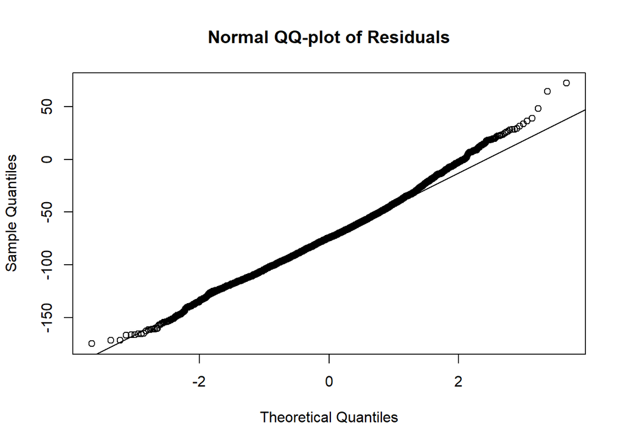

```r
res = residuals(tobit3)
qqnorm(res, main = "Normal QQ-plot of Residuals")
qqline(res)
```

### Homoskedasticity

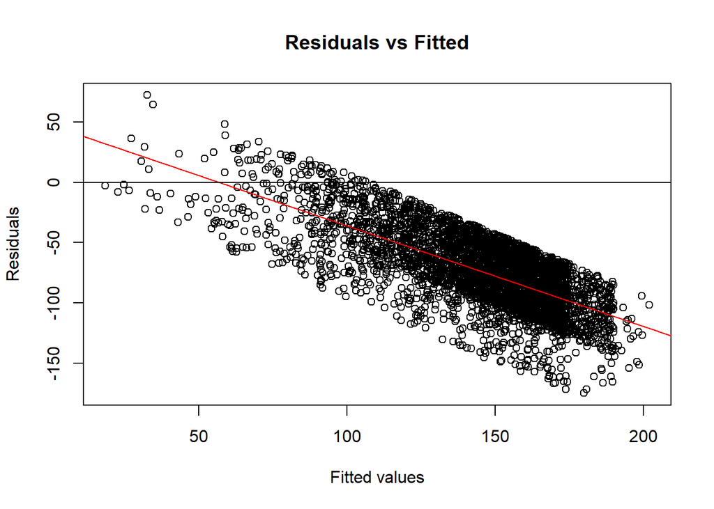

```r
plot(fitted(tobit3),
     res,
     main = "Residuals vs Fitted",
     xlab = "Fitted values",
     ylab = "Residuals")
abline(lm(res ~ fitted(tobit3)), col = "red")
abline(0, 0)
```